# project1

Rola Przemysław

2025-04-15

Datasety, które użyłem: Klasyfikacja obiektów na niebie https://www.kaggle.com/datasets/fedesoriano/stellar-classification-dataset-sdss17

Predykcja wieku gwiazdy: https://www.kaggle.com/datasets/fernandolima23/physical-parameters-of-cool-solartype-stars

```r
stars <- read.csv("Physical_parameters_of_stars_regression.csv")
stellar_objects <- read.csv("star_classification.csv")
```

# Regresja

## Predykcja wieku gwiazdy po jej parametrach

W ręce trafił mi zbiór, niestety bardzo mały, ale posiadający cechy zarejestrowanych obrazów gwiazd i ich estymowany wiek

```r
summary(stars)
```

```
##      Star                Teff          e_Teff            logg
##  Length:451         Min.   :4400   Min.   : 10.00   Min.   :3.600
##  Class :character   1st Qu.:5087   1st Qu.: 16.00   1st Qu.:4.330
##  Mode  :character   Median :5523   Median : 23.00   Median :4.400
##                     Mean   :5448   Mean   : 33.99   Mean   :4.379
##                     3rd Qu.:5791   3rd Qu.: 42.50   3rd Qu.:4.450
##                     Max.   :6431   Max.   :221.00   Max.   :4.820
##
##      e_logg              Vt              e_Vt           X.Fe.H.
##  Min.   :0.02000   Min.   :0.0000   Min.   :0.0100   Min.   :-0.83000
##  1st Qu.:0.04000   1st Qu.:0.6250   1st Qu.:0.0300   1st Qu.:-0.24000
##  Median :0.06000   Median :0.8400   Median :0.0400   Median :-0.08000
##  Mean   :0.08417   Mean   :0.8127   Mean   :0.1244   Mean   :-0.08936
##  3rd Qu.:0.10000   3rd Qu.:1.0200   3rd Qu.:0.0900   3rd Qu.: 0.08000
##  Max.   :0.48000   Max.   :2.1000   Max.   :2.2000   Max.   : 0.36000
##
##     e_.Fe.H.            Mass           e_Mass             Age
##  Min.   :0.01000   Min.   :0.700   Min.   :0.00000   Min.   : 0.152
##  1st Qu.:0.01000   1st Qu.:0.785   1st Qu.:0.01200   1st Qu.: 3.095
##  Median :0.02000   Median :0.891   Median :0.01600   Median : 4.476
##  Mean   :0.02149   Mean   :0.907   Mean   :0.01602   Mean   : 4.862
##  3rd Qu.:0.02000   3rd Qu.:1.009   3rd Qu.:0.02100   3rd Qu.: 6.205
##  Max.   :0.22000   Max.   :1.366   Max.   :0.04900   Max.   :11.749
##                    NA's   :10      NA's   :10        NA's   :5
##      e_Age
##  Min.   :0.0110
##  1st Qu.:0.6075
##  Median :2.3775
##  Mean   :2.3404
##  3rd Qu.:3.9975
##  Max.   :5.0370
##  NA's   :5
```

Zbiór jest praktycznie gotowy du użytku. Omijamy jedynie nazwę gwiazdy, trzeba też usunąć wiersze, które posiadają wartości `NA`

```r
stars <- stars[!is.na(stars$Age), ]
stars <- stars[!is.na(stars$Mass), ]
train_indices <- sample(1:nrow(stars), size = 0.7 * nrow(stars))

# pozbywamy się jedynie nazwy gwiazdy, są one nie istotne, pożcimy także ostatnią (błąd estymacji wieku), z racji iż mógłby zbytnio podpowiadać wiek gwiazdy (albo po prostu przeszkadzać)
train_stars <- stars[train_indices, -c(1, 13)]
test_stars <- stars[-train_indices, -c(1, 13)]
```

```r
model_stars <- lm(Age ~ ., data = train_stars)
summary(model_stars)
```

```
##
## Call:
## lm(formula = Age ~ ., data = train_stars)
##
## Residuals:
##     Min      1Q  Median      3Q     Max
## -3.3092 -0.9857 -0.1772  0.9554  4.5862
##
## Coefficients:
##               Estimate Std. Error t value Pr(>|t|)
## (Intercept)  7.388e+01  3.594e+00  20.556  < 2e-16 ***
## Teff         1.100e-02  8.822e-04  12.466  < 2e-16 ***
## e_Teff       4.601e-02  9.784e-03   4.702 3.94e-06 ***
## logg        -2.027e+01  9.137e-01 -22.189  < 2e-16 ***
## e_logg      -1.691e+01  4.177e+00  -4.048 6.58e-05 ***
## Vt           3.285e+00  7.926e-01   4.145 4.45e-05 ***
## e_Vt         9.254e-01  6.290e-01   1.471    0.142
## X.Fe.H.      2.872e+00  6.831e-01   4.205 3.46e-05 ***
## e_.Fe.H.     5.104e+00  5.938e+00   0.860    0.391
## Mass        -4.587e+01  2.161e+00 -21.223  < 2e-16 ***
## e_Mass      -9.128e+01  1.246e+01  -7.328 2.22e-12 ***
## ---
## Signif. codes:  0 '***' 0.001 '**' 0.01 '*' 0.05 '.' 0.1 ' ' 1
##
## Residual standard error: 1.453 on 297 degrees of freedom
## Multiple R-squared:  0.768,  Adjusted R-squared:  0.7602
## F-statistic: 98.33 on 10 and 297 DF,  p-value: < 2.2e-16
```

- dodatni wpływ posiadają Temperatura efektywna, Mikroturbulencje.
- negatywny wpływ ma masa oraz grawitacja powierzchniowa

```r
predictions <- predict(model_stars, newdata = test_stars)
actuals <- test_stars$Age

library(Metrics)
rmse(actuals, predictions)
```

```
## [1] 1.324224
```

```r
mae(actuals, predictions)
```

```
## [1] 1.097329
```

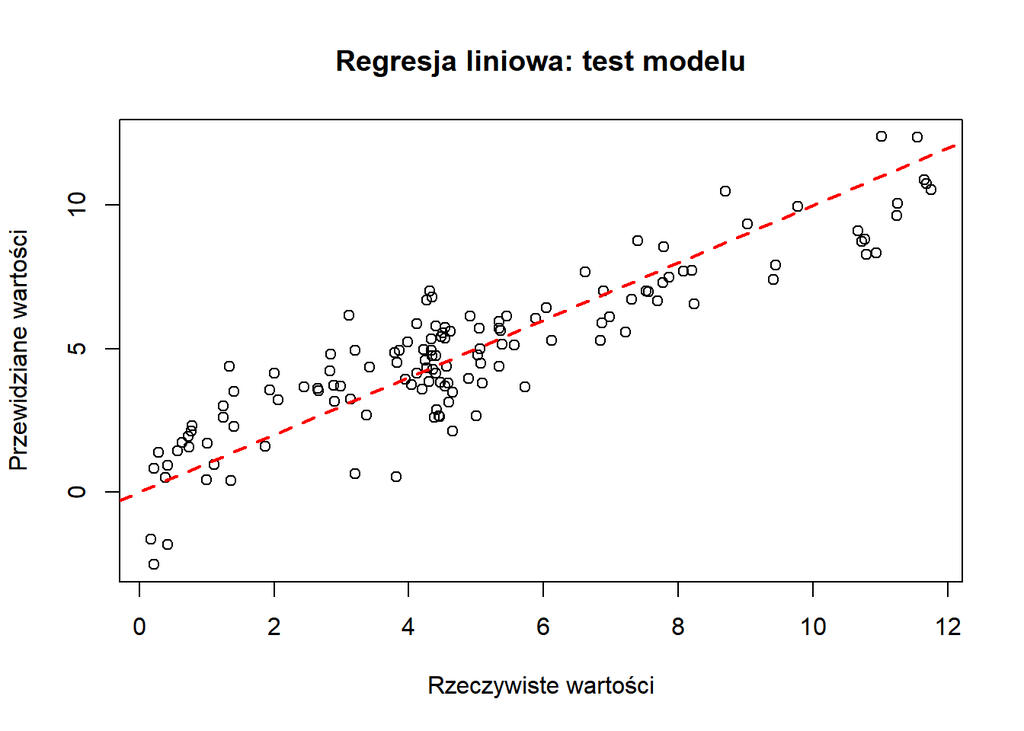

```r
plot(actuals, predictions,
     xlab = "Rzeczywiste wartości",
     ylab = "Przewidziane wartości",
     main = "Regresja liniowa: test modelu")
abline(a = 0, b = 1, col = "red", lty = 2, lwd = 2)
```

Jeden pomysł który przyszedł mi do głowy to podniesienie do kwadratu błędów które nie dawały efektów w pierwszym treningu

```r
model_stars_extended <- lm(Age ~ . + I(e_.Fe.H.^2) + I(e_Vt^2), data = train_stars)
summary(model_stars_extended)
```

```
##
## Call:
## lm(formula = Age ~ . + I(e_.Fe.H.^2) + I(e_Vt^2), data = train_stars)
##
## Residuals:
##     Min      1Q  Median      3Q     Max
## -3.2273 -0.9871 -0.2109  0.9009  4.6524
##
## Coefficients:
##                 Estimate Std. Error t value Pr(>|t|)
## (Intercept)    7.518e+01  3.608e+00  20.834  < 2e-16 ***
## Teff           1.112e-02  8.792e-04  12.645  < 2e-16 ***
## e_Teff         2.794e-02  1.116e-02   2.503 0.012855 *
## logg          -2.047e+01  9.008e-01 -22.726  < 2e-16 ***
## e_logg        -1.801e+01  4.172e+00  -4.317 2.16e-05 ***
## Vt             4.070e+00  8.218e-01   4.952 1.24e-06 ***
## e_Vt           6.470e+00  1.787e+00   3.620 0.000346 ***
## X.Fe.H.        3.672e+00  7.151e-01   5.136 5.12e-07 ***
## e_.Fe.H.       1.182e+01  1.489e+01   0.794 0.427757
## Mass          -4.775e+01  2.191e+00 -21.791  < 2e-16 ***
## e_Mass        -8.446e+01  1.247e+01  -6.772 6.89e-11 ***
## I(e_.Fe.H.^2)  2.364e+00  7.969e+01   0.030 0.976353
## I(e_Vt^2)     -2.834e+00  9.002e-01  -3.148 0.001812 **
## ---
## Signif. codes:  0 '***' 0.001 '**' 0.01 '*' 0.05 '.' 0.1 ' ' 1
##
## Residual standard error: 1.429 on 295 degrees of freedom
## Multiple R-squared:  0.7773, Adjusted R-squared:  0.7683
## F-statistic: 85.82 on 12 and 295 DF,  p-value: < 2.2e-16
```

```r
predictions_enxtended <- predict(model_stars_extended, newdata = test_stars)
rmse(actuals, predictions_enxtended)
```

```
## [1] 1.341674
```

```r
mae(actuals, predictions_enxtended)
```

```
## [1] 1.101356
```

Co jak widać nie polepsza, a wręcz pogarsza model

## Wnioski

Model był się w stanie dobrze nauczyć przewidywać wiek, ale jednak jest to trochę oszukany test - z racji iż sami wieku nie znamy, a jedynie jego przybliżenie.

# Klasyfikacja

```r
summary(stellar_objects)
```

```
##      obj_ID              alpha              delta               u
##  Min.   :1.238e+18   Min.   :  0.0055   Min.   :-18.785   Min.   :-9999.00
##  1st Qu.:1.238e+18   1st Qu.:127.5182   1st Qu.:  5.147   1st Qu.:   20.35
##  Median :1.238e+18   Median :180.9007   Median : 23.646   Median :   22.18
##  Mean   :1.238e+18   Mean   :177.6291   Mean   : 24.135   Mean   :   21.98
##  3rd Qu.:1.238e+18   3rd Qu.:233.8950   3rd Qu.: 39.902   3rd Qu.:   23.69
##  Max.   :1.238e+18   Max.   :359.9998   Max.   : 83.001   Max.   :   32.78
##        g                  r                i               z
##  Min.   :-9999.00   Min.   : 9.822   Min.   : 9.47   Min.   :-9999.00
##  1st Qu.:   18.96   1st Qu.:18.136   1st Qu.:17.73   1st Qu.:   17.46
##  Median :   21.10   Median :20.125   Median :19.41   Median :   19.00
##  Mean   :   20.53   Mean   :19.646   Mean   :19.08   Mean   :   18.67
##  3rd Qu.:   22.12   3rd Qu.:21.045   3rd Qu.:20.40   3rd Qu.:   19.92
##  Max.   :   31.60   Max.   :29.572   Max.   :32.14   Max.   :   29.38
##      run_ID        rerun_ID      cam_col         field_ID
##  Min.   : 109   Min.   :301   Min.   :1.000   Min.   : 11.0
##  1st Qu.:3187   1st Qu.:301   1st Qu.:2.000   1st Qu.: 82.0
##  Median :4188   Median :301   Median :4.000   Median :146.0
##  Mean   :4481   Mean   :301   Mean   :3.512   Mean   :186.1
##  3rd Qu.:5326   3rd Qu.:301   3rd Qu.:5.000   3rd Qu.:241.0
##  Max.   :8162   Max.   :301   Max.   :6.000   Max.   :989.0
##   spec_obj_ID           class              redshift             plate
##  Min.   :2.995e+17   Length:100000      Min.   :-0.009971   Min.   :  266
##  1st Qu.:2.844e+18   Class :character   1st Qu.: 0.054517   1st Qu.: 2526
##  Median :5.615e+18   Mode  :character   Median : 0.424173   Median : 4987
##  Mean   :5.784e+18                      Mean   : 0.576661   Mean   : 5137
##  3rd Qu.:8.332e+18                      3rd Qu.: 0.704154   3rd Qu.: 7400
##  Max.   :1.413e+19                      Max.   : 7.011245   Max.   :12547
##       MJD           fiber_ID
##  Min.   :51608   Min.   :   1.0
##  1st Qu.:54234   1st Qu.: 221.0
##  Median :55869   Median : 433.0
##  Mean   :55589   Mean   : 449.3
##  3rd Qu.:56777   3rd Qu.: 645.0
##  Max.   :58932   Max.   :1000.0
```

## Filtracja danych

Teraz usuwamy więcej niż z poprzedniego,gdyż:

- `alpha` i `delta` są współrzędnymi obiektu. Na dłuższą metę mógłby się przeuczyć, biorąc tylko to
- `obj_Id` oraz `spec_obj_ID` - id nie są cechami do nauki
- `field_ID` - pośrednia wartość miejsca, gdzie znajduje się ten obiekt

W ten sposób dostałem w miarę ogólne dane, to jest nei zwarzające z którego miejsca został uchwycony dany obraz, ale ma wszelkie informacje o parametrach uchwyconego zdjęcia

```r
train_indices_stellar <- sample(1:nrow(stellar_objects), size = 0.7 * nrow(stellar_objects))
stellar_objects$class <- as.factor(stellar_objects$class)

train_stellar <- stellar_objects[train_indices_stellar, -c(1, 2, 3, 12, 13)]
test_stellar <- stellar_objects[-train_indices_stellar, -c(1, 2, 3, 12, 13)]
```

Z racji posiadania 3 klas klasyfiacji, użyję `multinom()`

```r
library(nnet)
model_multi <- multinom(class ~ ., data = train_stellar)
summary(model_multi)
```

```
## Call:
## multinom(formula = class ~ ., data = train_stellar)
##
## Coefficients:
##        (Intercept)           u          g          r             i           z
## QSO  -0.0003153294 -0.57335496 -1.0318628 -0.3006054  1.2065965559  0.25630991
## STAR -0.0002761431  0.08669205 -0.3428513  0.1790929 -0.0006663071 -0.04987195
##             run_ID    rerun_ID    cam_col    redshift         plate
## QSO  -6.795938e-05 -0.09487238 0.03900515    5.503633 -0.0004440754
## STAR -4.915368e-05 -0.08305866 0.04758743 -852.386070 -0.0004705053
##               MJD      fiber_ID
## QSO  0.0006720183  0.0001156322
## STAR 0.0006105358 -0.0005299938
##
## Std. Errors:
##       (Intercept)            u            g            r            i
## QSO  2.404585e-10 3.703694e-08 3.885574e-08 3.021854e-08 2.443105e-08
## STAR 5.041886e-10 6.679588e-08 5.618777e-08 8.011707e-08 8.017369e-08
##                 z       run_ID     rerun_ID      cam_col     redshift
## QSO  1.674824e-08 1.264956e-05 7.237802e-08 4.331727e-08 2.793675e-09
## STAR 7.576689e-08 2.687886e-05 1.517608e-07 1.668511e-07 8.499748e-12
##             plate          MJD     fiber_ID
## QSO  7.760871e-06 1.388821e-06 8.601035e-05
## STAR 1.756256e-05 3.087874e-06 2.009531e-04
##
## Residual Deviance: 17235.96
## AIC: 17283.96
```

W pierwszej próbie tego modelu nie usunąłem tylu kolumn i model uczył się w większośći po współrzędnych. Teraz widzimy, że najważniejszymi parametrami są pochodne światła które do nas dotarło.

```r
predictions_stellar <- predict(model_multi, newdata = test_stellar)
actuals_stellar <- test_stellar$class

confusion_matrix <- table(Predicted = predictions_stellar, Actual = actuals_stellar)
print(confusion_matrix)
```

```
##          Actual
## Predicted GALAXY   QSO  STAR
##    GALAXY  17445   660     2
##    QSO       261  4960     2
##    STAR      151     1  6518
```

## Wnioski

Pomimo wyciągnięcia tylu danych ze zbioru, model dalej był w stanie się w miarę dobrze nauczyć rozróżniać poszczególne klasy. Najwięcej problemu sprawia mu rozróznienie kwazara od galaktyki.